# Google Data Analytics Capstone: Analyze annual data of bike - Cyclist

Author: Đỗ Việt Hưng

Creation Date: 2023-07-09

#### Case Study: How Does A Bike-Share Navigate Speedy Success?

In this Case Study, I took on the role of a Junior Data Analyst at a hypothetical company - Cyclist, I tasked with analyzing data from the first 5 months of 2023 to support answering business questions for the company’s upcoming marketing campaign

I will follow the steps of the data analysis process: Ask, Prepare, Process, Analyze and Share

## I. Ask

### Business Task

Provide marketing strategies to convert casual riders into member riders

### Analysis questions

1. How do members riders and causual riders differ in their use of Cyclistic bikes?
2. Why do regular riders purchase Cyclistic’s annual membership?
3. How can Cyclistic utilize digital platforms to influence regular riders to become members?

Moreno assigned me the first question to answer: How do members riders and causual riders differ in their use of Cyclistic bikes?

## II. Prepare

### Resource

I utilize Cyclistc’s historical data to conduct analysis and identify trends over the first 5 months of 2023

Data has been collected from [divvy_tripdata](https://divvy-tripdata.s3.amazonaws.com/index.html). Provided by Motivate International under this [license](https://ride.divvybikes.com/data-license-agreement)

## III. Process

### 1. Combine Data

Utilize data from 01/2023 to 05/2023

- [divvy_tripdata_01_2023](https://divvy-tripdata.s3.amazonaws.com/202301-divvy-tripdata.zip)
- [divvy_tripdata_02_2023](https://divvy-tripdata.s3.amazonaws.com/202302-divvy-tripdata.zip)
- [divvy_tripdata_03_2023](https://divvy-tripdata.s3.amazonaws.com/202303-divvy-tripdata.zip)
- [divvy_tripdata_04_2023](https://divvy-tripdata.s3.amazonaws.com/202304-divvy-tripdata.zip)
- [divvy_tripdata_05_2023](https://divvy-tripdata.s3.amazonaws.com/202305-divvy-tripdata.zip)

#### Conncet to SQL Server in R language

Install Packages to connect with SQL

```
install.packages("odbc")

install.packages("DBI")

install.packages("tidyverse")
```

In there:

- Package “odbc” allow connect with Database of SQL Server
- Package “DBI” allow interact with Database

Utilize libary of packages

```r
library(odbc)

library(DBI)

library(ggplot2)
```

Combine data of 5 tables into single table

```sql
IF NOT EXISTS (SELECT 1 FROM sys.tables WHERE name = 'divvy_tripdata_2023')
BEGIN
    SELECT * INTO divvy_tripdata_2023
    FROM (
        SELECT * FROM divvy_tripdata_01_2023
        UNION ALL
        SELECT * FROM divvy_tripdata_02_2023
        UNION ALL
        SELECT * FROM divvy_tripdata_03_2023
        UNION ALL
        SELECT * FROM divvy_tripdata_04_2023
        UNION ALL
        SELECT * FROM divvy_tripdata_05_2023 ) AS row_data
END

SELECT COUNT(*) AS count
    FROM divvy_tripdata_2023
```

1 records

| count |
| --- |
| 1670841 |

### 2. Data Exploration

The following table shows all field name and data type of table ‘divvy_tripdata_2023’

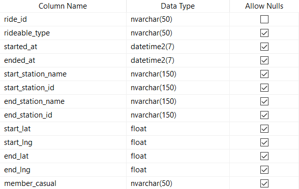

The query bellow shows the number of **NULL** vaule per field

```sql
SELECT
    COUNT(CASE WHEN ride_id IS NULL THEN 1 ELSE NULL END) AS ride_id,
    COUNT(CASE WHEN rideable_type IS NULL THEN 1 ELSE NULL END) AS rideable_type,
    COUNT(CASE WHEN started_at IS NULL THEN 1 ELSE NULL END) AS started_at,
    COUNT(CASE WHEN ended_at IS NULL THEN 1 ELSE NULL END) AS ended_at,
    COUNT(CASE WHEN start_station_name IS NULL THEN 1 ELSE NULL END) AS start_station_name,
    COUNT(CASE WHEN start_station_id IS NULL THEN 1 ELSE NULL END) AS start_station_id,
    COUNT(CASE WHEN end_station_name IS NULL THEN 1 ELSE NULL END) AS end_station_name,
    COUNT(CASE WHEN end_station_id IS NULL THEN 1 ELSE NULL END) AS end_station_id,
    COUNT(CASE WHEN start_lat IS NULL THEN 1 ELSE NULL END) AS start_lat,
    COUNT(CASE WHEN start_lng IS NULL THEN 1 ELSE NULL END) AS start_lng,
    COUNT(CASE WHEN end_lat IS NULL THEN 1 ELSE NULL END) AS end_lat,
    COUNT(CASE WHEN end_lng IS NULL THEN 1 ELSE NULL END) AS end_lng,
    COUNT(CASE WHEN member_casual IS NULL THEN 1 ELSE NULL END) AS member_casual
FROM divvy_tripdata_2023
```

1 records

| ride_id | rideable_type | started_at | ended_at | start_station_name | start_station_id | end_station_name | end_station_id | start_lat | start_lng | end_lat | end_lng | member_casual |
| --- | --- | --- | --- | --- | --- | --- | --- | --- | --- | --- | --- | --- |
| 0 | 0 | 0 | 0 | 241158 | 241290 | 256913 | 257054 | 0 | 0 | 1571 | 1571 | 0 |

**Observation:**

- The *start_station_name* field has **241,158** **NULL** values and needs to be removed
- The *start_station_id* field has **241,290** **NULL** values and needs to be removed
- The *end_station_name* field has **256,913** **NULL** values and needs to be removed
- The *end_station_id* field has **257,054** **NULL** values and needs to be removed
- The *end_lat* and *end_lng* both fields have **1,571** **NULL** values and needs to be removed

Due to *rise_id* field is a **Primary Key**, there will be no duplicate values

### 3. Data Cleaning

Create a new column named *rise_length* to determine the duration of each trip (in minute format).

All records containing **NULL** values will be removed

```sql
IF NOT EXISTS (SELECT 1 FROM sys.tables WHERE name = 'pre_clean_combined_data')
BEGIN
    SELECT * INTO pre_clean_combined_data
    FROM (
        SELECT ride_id, rideable_type,
          CAST(DATENAME(hh, started_at) AS INT) AS hour,
            DATENAME(dw, started_at) AS day_of_week,
            DAY(started_at) AS day,
            MONTH(started_at) AS month,
            YEAR(started_at) AS year,
            -- Cast the data type of the DateDiff function result to the round result of the division to 2 decimal places
            ROUND(CAST(DATEDIFF(s, started_at, ended_at) AS float)/60, 2) AS ride_length_minute,
            start_station_name, end_station_name, start_lat, start_lng,
            end_lat, end_lng, member_casual
        FROM divvy_tripdata_2023
        WHERE start_station_name IS NOT NULL AND
            start_station_id IS NOT NULL AND
            end_station_name IS NOT NULL AND
            end_station_id IS NOT NULL AND
            end_lat IS NOT NULL AND
            end_lng IS NOT NULL
    ) AS cleaned
END

-- Sorting ride_length_minute column in ascending
SELECT TOP(10) * FROM pre_clean_combined_data
    ORDER BY ride_length_minute ASC
```

Displaying records 1 - 10

| ride_id | rideable_type | hour | day_of_week | day | month | year | ride_length_minute | start_station_name | end_station_name | start_lat | start_lng | end_lat | end_lng | member_casual |
| --- | --- | --- | --- | --- | --- | --- | --- | --- | --- | --- | --- | --- | --- | --- |
| A769AB597DEA18C4 | classic_bike | 5 | Saturday | 27 | 5 | 2023 | -0.23 | Southport Ave & Belmont Ave | Southport Ave & Belmont Ave | 41.93948 | -87.66375 | 41.93948 | -87.66375 | member |
| 934174DB8E2AD791 | classic_bike | 17 | Monday | 29 | 5 | 2023 | -0.20 | Lakefront Trail & Bryn Mawr Ave | Lakefront Trail & Bryn Mawr Ave | 41.98404 | -87.65228 | 41.98404 | -87.65228 | member |
| 00AC4040E25E347E | classic_bike | 15 | Sunday | 7 | 5 | 2023 | -0.18 | Wentworth Ave & Cermak Rd* | Wentworth Ave & Cermak Rd* | 41.85321 | -87.63187 | 41.85321 | -87.63187 | casual |
| 97BF63D06721A3B9 | classic_bike | 18 | Saturday | 13 | 5 | 2023 | -0.10 | Wentworth Ave & Cermak Rd* | Wentworth Ave & Cermak Rd* | 41.85321 | -87.63187 | 41.85321 | -87.63187 | member |
| 0063C3704F56EC55 | electric_bike | 7 | Thursday | 27 | 4 | 2023 | -0.08 | Green St & Randolph St* | Green St & Randolph St* | 41.88346 | -87.64860 | 41.88360 | -87.64863 | casual |
| 81E1C5175FA5A23D | classic_bike | 14 | Wednesday | 19 | 4 | 2023 | -0.07 | Green St & Randolph St* | Green St & Randolph St* | 41.88360 | -87.64863 | 41.88360 | -87.64863 | member |
| 7A4D237E2C99D424 | electric_bike | 17 | Tuesday | 4 | 4 | 2023 | -0.05 | Green St & Randolph St* | Green St & Randolph St* | 41.88361 | -87.64856 | 41.88360 | -87.64863 | member |
| 579596DD4C7C7538 | classic_bike | 17 | Tuesday | 23 | 5 | 2023 | -0.05 | Wentworth Ave & Cermak Rd* | Wentworth Ave & Cermak Rd* | 41.85321 | -87.63187 | 41.85321 | -87.63187 | casual |
| 1CEB299B0AACB63F | electric_bike | 16 | Wednesday | 19 | 4 | 2023 | 0.00 | Desplaines St & Kinzie St | Desplaines St & Kinzie St | 41.88850 | -87.64436 | 41.88872 | -87.64445 | casual |
| BF7BE067A7FD077A | electric_bike | 7 | Tuesday | 18 | 4 | 2023 | 0.00 | California Ave & Division St | California Ave & Division St | 41.90303 | -87.69754 | 41.90303 | -87.69747 | member |

**Observation:**

- The result-set in *ride_length_minute* column have 8 values with value < 0
- The cause may be due to user error or system error when inserting data into the database

```sql
-- Remove records that *ride_length_minute* value < 0

IF NOT EXISTS (SELECT 1 FROM sys.tables WHERE name = 'clean_combined_data')
BEGIN
    SELECT * INTO clean_combined_data
    FROM (
        SELECT * FROM pre_clean_combined_data
        wHERE ride_length_minute >= 0 ) AS completely_clean
END

-- Count the number of records in *clean_combined_data*
SELECT COUNT(*) AS count
    FROM clean_combined_data
```

1 records

| count |
| --- |
| 1285707 |

In this way, after the data clean step, a new table named *clean_combined_data* will be obtained with **1,285,707 records**

## IV. Analyze And Share

### 1. Statitics Analysis

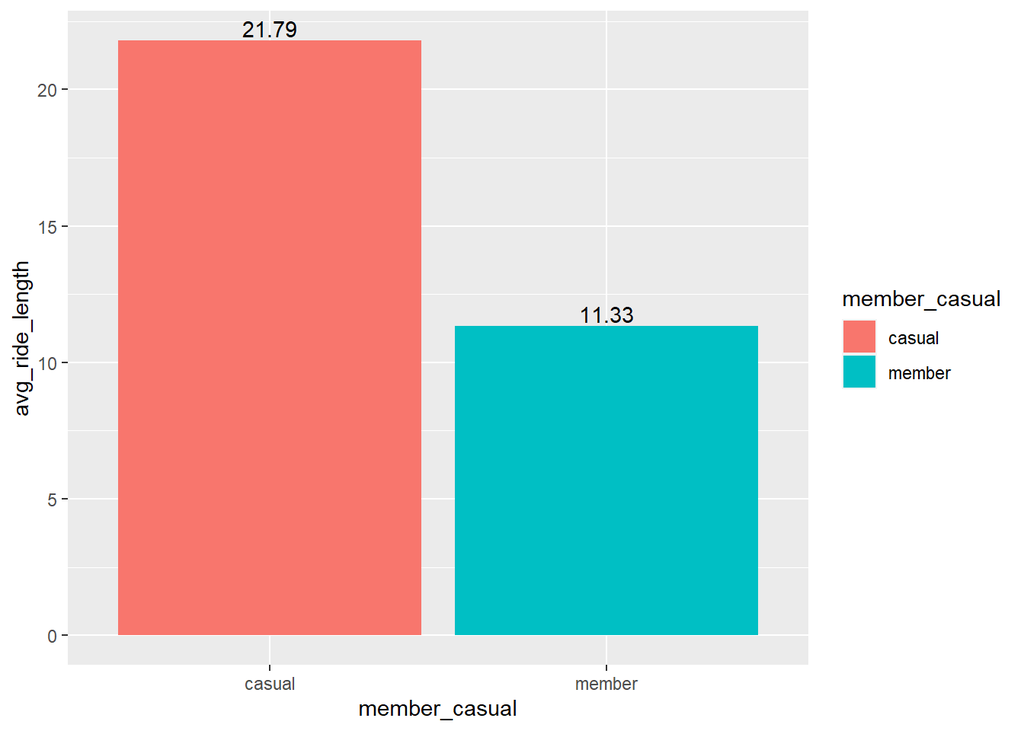

```r
query = "SELECT
              member_casual,ROUND(AVG(ride_length_minute), 2) AS avg_ride_length
         FROM clean_combined_data
         GROUP BY member_casual"

result = dbGetQuery(con, query)

# Visualization

ggplot(data = result) +
  geom_bar(stat = "identity", mapping = aes(x = member_casual, y = avg_ride_length, fill = member_casual)) +
  geom_text(aes(x = member_casual, y = avg_ride_length, label = avg_ride_length), vjust = -0.25)
```

### 2. Analysis of a number of member riders and casual riders

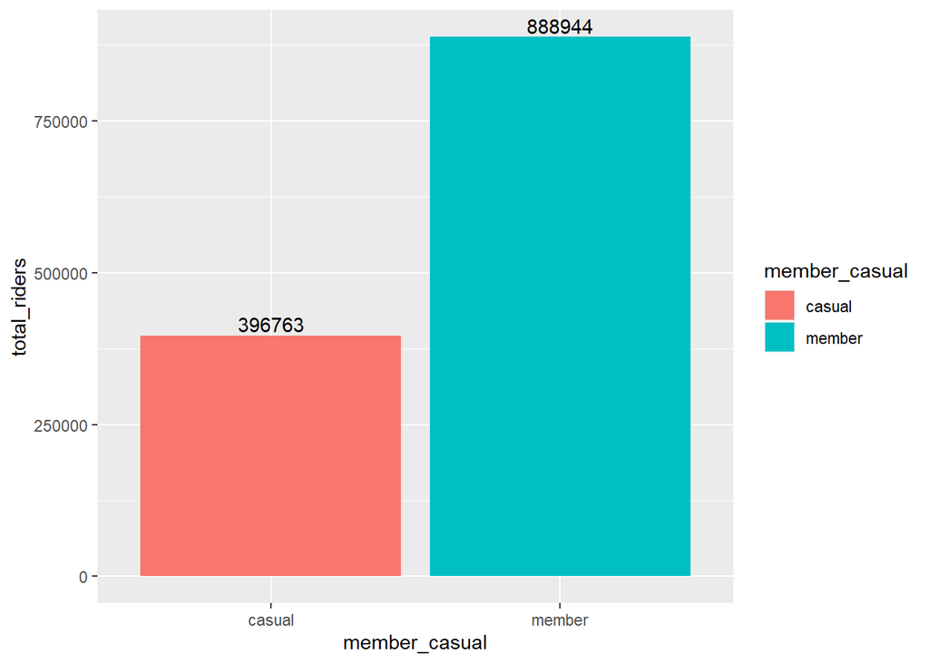

```r
query = "SELECT member_casual, count(member_casual) AS total_riders
            FROM clean_combined_data
            GROUP BY member_casual"

riders_rs = dbGetQuery(con, query)

# Visualization

ggplot(data = riders_rs) +
  geom_bar(stat = "identity", mapping = aes(x = member_casual, y = total_riders, fill = member_casual)) +
  geom_text(aes(x = member_casual, y = total_riders, label = total_riders), vjust = -0.25)
```

### 3. Analysis of a number of member riders and casual riders from vehicle type

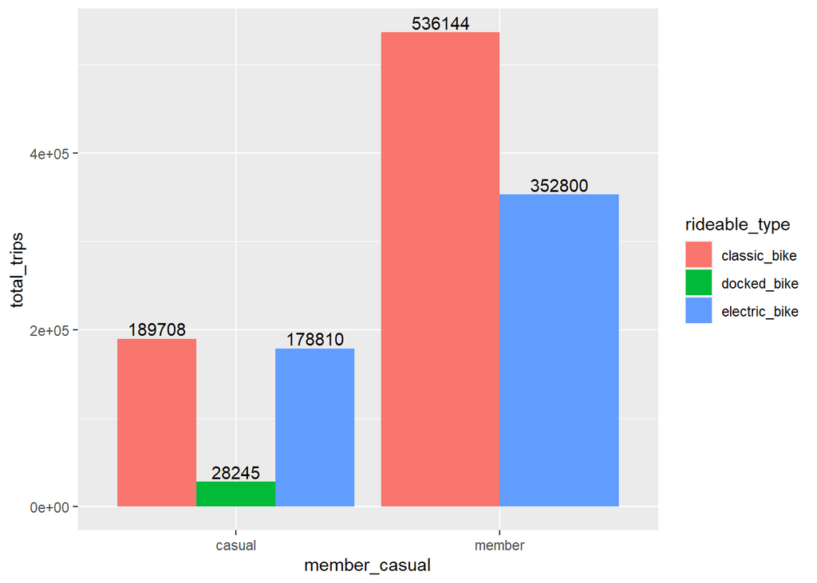

```r
query = "SELECT
              member_casual, rideable_type,
              COUNT(*) AS total_trips
         FROM clean_combined_data
         GROUP BY member_casual, rideable_type"

result = dbGetQuery(con, query)

# Visualization

ggplot(result, aes(x = member_casual, y = total_trips, fill = rideable_type)) +
  geom_col(position = "dodge") +
  geom_text(aes(label = total_trips), position = position_dodge(width = 0.9), vjust = -0.25)
```

### 4. Analysis of total travel time per ride for member riders and casual riders from month, weekday and hour

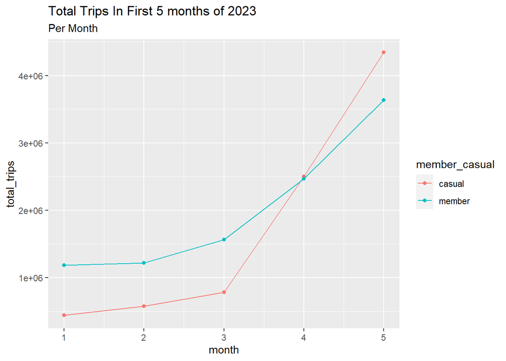

```r
query = "SELECT
              member_casual, month,
            ROUND(SUM(ride_length_minute), 2) AS total_trips
         FROM clean_combined_data
         GROUP BY month, member_casual
         ORDER BY member_casual, month"

result = dbGetQuery(con, query)

# Visualization
ggplot(data = result, aes(x = month, y = total_trips, group = as.factor(member_casual), color = member_casual)) + geom_line() + geom_point() + labs(title = "Total Trips In First 5 months of 2023", subtitle = "Per Month")
```

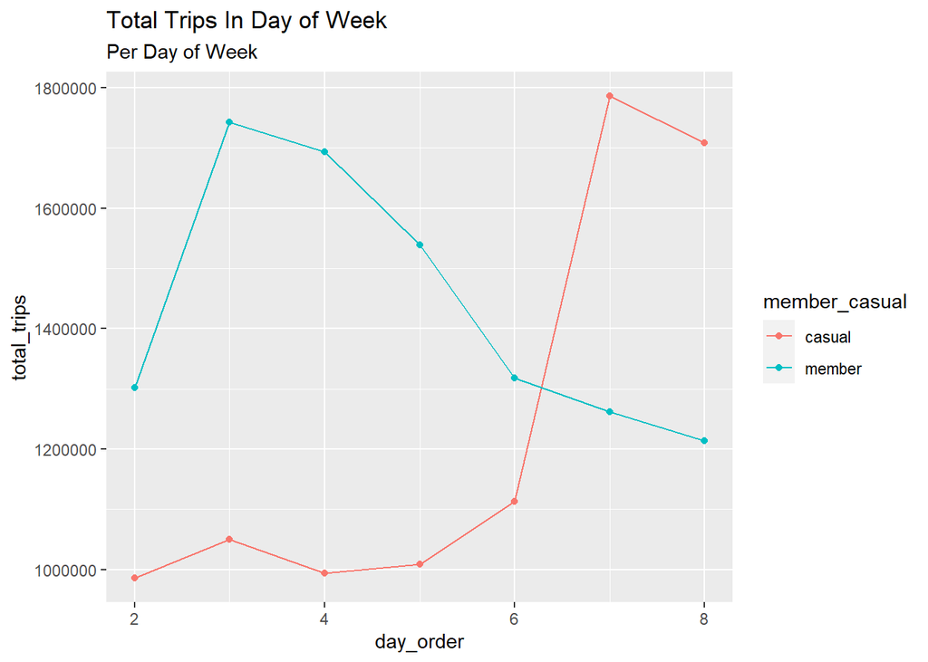

```r
query = "SELECT member_casual, day_of_week,
            CASE day_of_week
                WHEN 'Monday' THEN 2
                WHEN 'Tuesday' THEN 3
                WHEN 'Wednesday' THEN 4
                WHEN 'Thursday' THEN 5
                WHEN 'Friday' THEN 6
                WHEN 'Saturday' THEN 7
                WHEN 'Sunday' THEN 8
            END AS day_order,
              ROUND(SUM(ride_length_minute), 2) AS total_trips
         FROM clean_combined_data
         GROUP BY day_of_week, member_casual
         ORDER BY member_casual, day_order"

result = dbGetQuery(con, query)

# Visualization
ggplot(data = result, aes(x = day_order, y = total_trips, group = as.factor(member_casual), color = member_casual)) + geom_line() + geom_point() + labs(title = "Total Trips In Day of Week", subtitle = "Per Day of Week")
```

**Observation:** With the visual chart ‘Total Trips In Day of Week,’ members and casual riders exhibit contrasting travel behaviors. Member riders have higher travel time on weekdays and gradually decrease from Wednesday onwards, while casual riders have travel time on weekdays and significantly increase on the weekends

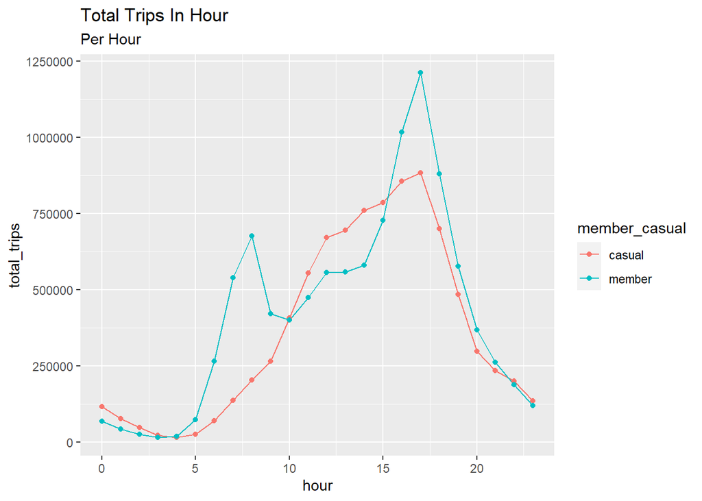

```r
query = "SELECT
              member_casual, hour,
            ROUND(SUM(ride_length_minute), 2) AS total_trips
         FROM clean_combined_data
         GROUP BY hour, member_casual
         ORDER BY member_casual, hour"

result = dbGetQuery(con, query)

# Visualization
ggplot(data = result, aes(x = hour, y = total_trips, group = as.factor(member_casual), color = member_casual)) + geom_line() + geom_point() + labs(title = "Total Trips In Hour", subtitle = "Per Hour")
```

### 5. Analysis of average travel time per ride for member riders and casual riders from month, weekday and hour

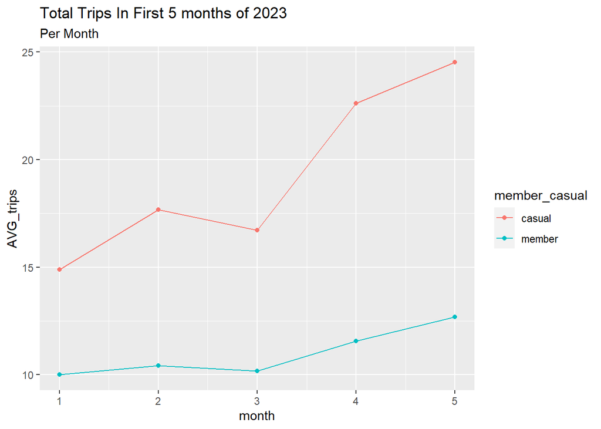

```r
query = "SELECT
              member_casual, month,
            ROUND(AVG(ride_length_minute), 2) AS AVG_trips
         FROM clean_combined_data
         GROUP BY month, member_casual
         ORDER BY member_casual, month"

result = dbGetQuery(con, query)

# Visualization
ggplot(data = result, aes(x = month, y = AVG_trips, group = as.factor(member_casual), color = member_casual)) + geom_line() + geom_point() + labs(title = "Total Trips In First 5 months of 2023", subtitle = "Per Month")
```

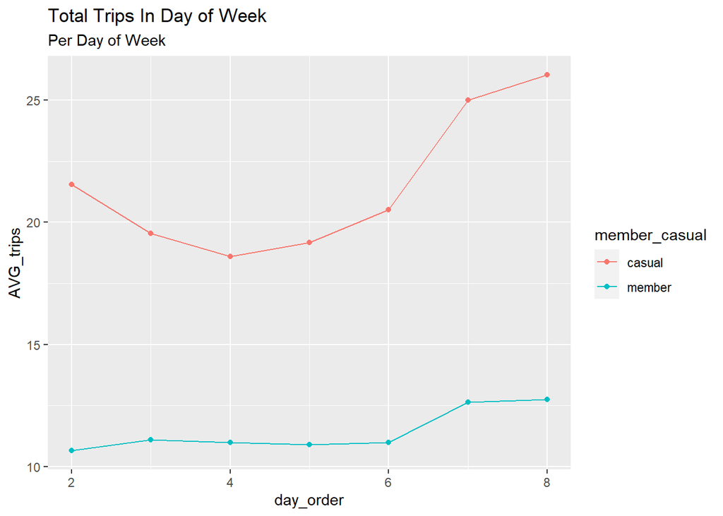

```r
query = "SELECT member_casual, day_of_week,
            CASE day_of_week
                WHEN 'Monday' THEN 2
                WHEN 'Tuesday' THEN 3
                WHEN 'Wednesday' THEN 4
                WHEN 'Thursday' THEN 5
                WHEN 'Friday' THEN 6
                WHEN 'Saturday' THEN 7
                WHEN 'Sunday' THEN 8
            END AS day_order,
              ROUND(AVG(ride_length_minute), 2) AS AVG_trips
         FROM clean_combined_data
         GROUP BY day_of_week, member_casual
         ORDER BY member_casual, day_order"

result = dbGetQuery(con, query)

# Visualization
ggplot(data = result, aes(x = day_order, y = AVG_trips, group = as.factor(member_casual), color = member_casual)) + geom_line() + geom_point() + labs(title = "Total Trips In Day of Week", subtitle = "Per Day of Week")
```

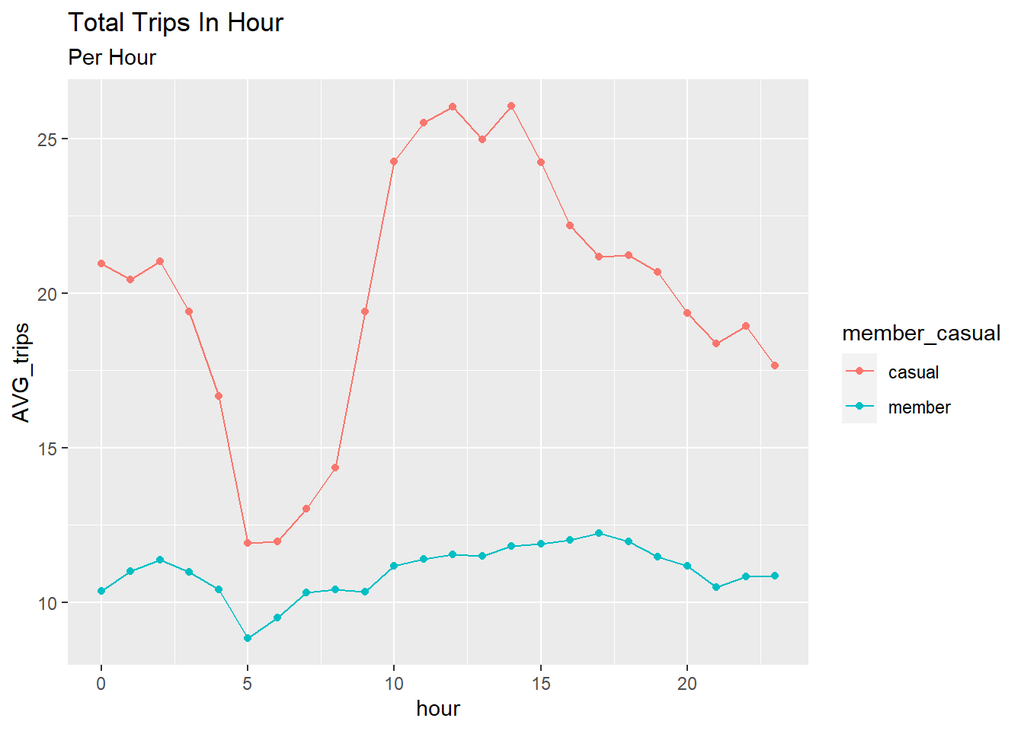

```r
query = "SELECT
              member_casual, hour,
            ROUND(AVG(ride_length_minute), 2) AS AVG_trips
         FROM clean_combined_data
         GROUP BY hour, member_casual
         ORDER BY member_casual, hour"

result = dbGetQuery(con, query)

# Visualization
ggplot(data = result, aes(x = hour, y = AVG_trips, group = as.factor(member_casual), color = member_casual)) + geom_line() + geom_point() + labs(title = "Total Trips In Hour", subtitle = "Per Hour")
```

### Reference

[Kaggle](https://www.kaggle.com/code/mmaguire/google-data-analytics-capstone-case-study-1#Introduction:)